```python
import plotly.plotly as py
import pandas as pd
from plotly.graph_objs import *
```

# CS5631: Data Visualization

## Exercise 2 Srihari Raghavendra Rao

### Understanding the data

- The given dataset is a temporal dataset containing 10 attributes, 9 of which are quantitative attributes (or metrics) and has one categorical attribute with sequential ordering.
- The dataset given is a time-series dataset as we have the dataset in the format of (t,x) where t = time attribute and x=values.
- The snowfall data was collected for the months October, November, December, January, February, March, April, May which can be further classified as seasons.

> October, November - Fall December, January, February - Winter March, April, May - Spring

### Data pre-processing

The given data needs to processed for better analysis. Some of the pre-processing task performed are:

- Rename headers such as "Winter" to "Year" and also the month headers were replaced with full month name, Ex: January rather than jan.
- The year attribute renamed above was of the form YYYY-(YYYY+1) starting from month October to May next year. This was rearranged to the format of YYYY. For example: the first item of the dataset had the year 1890-1891 starting from year 1890 October to 1891 May which was split into 2 items such as 1890 and 1891. The unavailable data for months [January to May] for the year 1890 was replaced with zero (assuming no snowfall for analysis purposes).
- Changed the data types of the columns to float to have consistency across the dataset.

Below we can see a snapshot of the dataset before pre-processing.

```python
df2 = pd.read_excel("Houghton-Snowfall-Records.xlsx")
df2.head()
```

|  | Winter | Oct. | Nov. | Dec. | Jan. | Feb. | Mar. | Apr. | May | Total Inches |
| --- | --- | --- | --- | --- | --- | --- | --- | --- | --- | --- |
| 0 | 1890-91 | 1.0 | 12.2 | 12.0 | 33.0 | 28.5 | 22.00 | 2.5 | 0.0 | 111.20 |
| 1 | 1891-92 | 0.0 | 31.0 | 23.0 | 44.0 | 18.0 | 12.50 | 1.0 | 0.0 | 129.50 |
| 2 | 1892-93 | 0.0 | 23.0 | 44.0 | 24.5 | 16.5 | 17.00 | 13.0 | 1.0 | 139.00 |
| 3 | 1893-94 | 1.0 | 30.0 | 48.5 | 37.0 | 14.5 | 23.00 | 10.0 | 1.0 | 165.00 |
| 4 | 1894-95 | 0.0 | 29.5 | 18.3 | 74.0 | 9.0 | 5.25 | 0.0 | 1.5 | 137.55 |

```python
Below we can see a snapshot of the dataset after pre-processing.
```

```python
df = pd.read_excel("HoughtonSnowfallNew.xlsx")
```

```python
df.head()
```

|  | Year | January | February | March | April | May | October | November | December | Total Inches |
| --- | --- | --- | --- | --- | --- | --- | --- | --- | --- | --- |
| 0 | 1890 | 0.0 | 0.0 | 0.0 | 0.0 | 0.0 | 1.0 | 12.2 | 12.0 | 111.20 |
| 1 | 1891 | 33.0 | 28.5 | 22.0 | 2.5 | 0.0 | 0.0 | 31.0 | 23.0 | 129.50 |
| 2 | 1892 | 44.0 | 18.0 | 12.5 | 1.0 | 0.0 | 0.0 | 23.0 | 44.0 | 139.00 |
| 3 | 1893 | 24.5 | 16.5 | 17.0 | 13.0 | 1.0 | 1.0 | 30.0 | 48.5 | 165.00 |
| 4 | 1894 | 37.0 | 14.5 | 23.0 | 10.0 | 1.0 | 0.0 | 29.5 | 18.3 | 137.55 |

Now that we have our dataset prepared for further analysis. Time to analyze the dataset!

### Data Abstraction

- Dataset: Houghton Snowfall dataset
- Dataset type: Table
- Attributes: </br>

  There are 10 attributes and 128 items corresponding to 128 years snowfall data in the dataset.

The trend of total snowfall (in inches) appears to be increasing over the years. There are a few interesting points:

- We can see that from 1890 to 1920, the snowfall gradually decreases and from 1920 to 1992 we see an increasing trend of the amount of snowfall after which interestingly the snowfall amount starts to reduce again until current date.
- The maximum and minimum snowfall observed are during 1978 with a record snowfall of 355.9 inches and during 1930 with a mere 81.29 inches of snow.

Here I have considered using both linear fit and a polynomial fit to find the amount of snowfall over the years in Houghton. We can see that using a linear curve fitting shows an increasing trend while using a polynomial curve fitting indicates a decreasing trend from the year 2000 till date.

The snowfall distribution over the years is not linear, hence using a polynomial of degree 3 clearly captures structure of the data.

Forecast:

- Here we have forecasted using both linear regression and polynomial regression. Even though the linear regression appears appealing it fails to fit the snowfall distribution whereas a polynomial regression clearly fits the data better but is overfitting the dataset. In order to better generalize the curve fitting we can resort to polynomial of degree 2 which better generalizes the curve fit. Based on this, the forecast appears to have a gradual increase initially until 2009 and starts to gradually decrease going ahead.

```python
import plotly
from plotly.offline import download_plotlyjs, init_notebook_mode, plot, iplot
import plotly.graph_objs as go
import numpy as np

init_notebook_mode(connected=True)
```

```python
trace1 = go.Scatter(x=df["Year"],y=df["Total Inches"],mode="lines",name="overallTrend")

x5=df.iloc[:,0].values
y5=df.iloc[:,9].values
z = np.polyfit(x5, y5, 3)
f = np.poly1d(z)
x_new = np.append(x5,np.arange(2018,2030,1))
y_new = f(x_new)

trace2 = go.Scatter(x=x_new,y=y_new,mode="lines",name="Polynomial Fit(Degree 3)",line=dict(color = 'rgb(0, 255, 0)'))

x7=df.iloc[:,0].values
y7=df.iloc[:,9].values
z2 = np.polyfit(x7, y7, 2)
f2 = np.poly1d(z2)
x_new2 = np.append(x7,np.arange(2018,2030,1))
y_new2 = f2(x_new2)

trace4 = go.Scatter(x=x_new2,y=y_new2,mode="lines",name="Polynomial Fit(Degree 2)",line=dict(color = 'rgb(255, 0, 0)'))


x6=df.iloc[:,0].values
y6=df.iloc[:,9].values
z1 = np.polyfit(x6, y6, 1)
f1 = np.poly1d(z1)
x_new1 = np.append(x6,np.arange(2018,2030,1))
y_new1 = f1(x_new1)

trace3 = go.Scatter(x=x_new1,y=y_new1,mode="lines",name="Linear Fit",line=dict(color = 'rgb(255,165,0)'))

data = [trace1,trace2,trace3,trace4]

layout = go.Layout(
    title = "Snowfall trend",
    xaxis=dict(
        autotick=True,
        tickcolor='#000',
        title='Year',
        titlefont=dict(
            family='Arial, sans-serif',
            size=18
        ),
        showticklabels=True
    ),
    yaxis=dict(
        autotick=True,
        tickcolor='#000',
        title='Total Snowfall (Inches)',
        titlefont=dict(
            family='Arial, sans-serif',
            size=18
        ),
        showticklabels=True
    ),
    shapes=[
        dict(
            type='rect',
            # x-reference is assigned to the x-values
            xref='x',
            # y-reference is assigned to the plot paper [0,1]
            yref='paper',
            x0=2018,
            y0= 0,
            x1=2030,
            y1= 0.9,
            #fillcolor='#d3d3d3',
            opacity=0.4,
            line=dict(
                width= 5)
            )
    ],
    annotations=[
        dict(
            x=2024,
            y=1,
            xref='x',
            yref='paper',
            text='Forecasted Years',
            #showarrow=True,
            #arrowhead=7,
            ax=0,
            ay=-40
        )
    ]
)

fig = go.Figure(data=data, layout=layout)
iplot(fig)
```

[interactive chart not shown]

#### 2.Which months contribute more toward the total snowfall over the years?

It can be seen that December and January are the months where there is higher snowfall and hence comparatively higher than all other months. We have used compare action here with multiple targets such as month attributes.

We also see a pattern in the percentage of snowfall/month over the years from the above plot. Smoothing the curves we can see a sinusoidal or periodic increase and decrease in the amount of snowfall percentage by the month December and January.

[figure not shown]

#### 3. How does the overall distribution look like? Does amount of snowfall insome months affect/influence others?

Parallel coordinate help us visualize the high dimensional dataset such as our current dataset. Also they provide the big picture of the distribution and relationship between the datasets.

- We can also infer that the highest snowfall was recorded in december.
- From the plot it is evident that the month of december shows huge variation in the amount of snowfall over the years. Similarly the month of January also shows high variation.
- Whereas the month of october, april and may show very less variation. This behavior is also evidently seen and depicted in moving average plots.
- With the help of parallel coordinates, we can also recognize outliers or anomalies. But parallel coordinates plots are not very accurate in doing so and can be used as a crude visual check on outliers. We can see two outliers clearly from the plot below.
- The main question that parallel coordinates is to find the relationship between multiple attributes. One of the downsides is that we can only compare adjacent dimensions, However this is overcome by moving the dimensions.
- However in the plot below, we do not see any significant correlations between the attributes. This is also evident from the correlation matrix computed using pearson method.

> The below plot provides interactivity to the user allowing to move the dimensions axes around to find interesting patterns and relationship by holding on the Name of the Dimension and dragging left or right. Also we can select and view a part of the parallel coordinate plot by dragging the pointer along the dimenstion axis.

```python
anotate = "Highest snowfall ="+str(df["December"].max())
data = [
    go.Parcoords(
        dimensions = list([
            dict(range = [0,140],label = 'October', values = df['October'],tickvals=[0,df["October"].max(),140]),
            dict(range = [0,140],label = 'November', values = df['November'],tickvals=[0,df["November"].max(),140]),
            dict(range = [0,140],label = 'December', values = df['December'],tickvals=[0,df["December"].max(),140],ticktext=[0,anotate,140]),
            dict(range = [0,140],label = 'January', values = df['January'],tickvals=[0,df["January"].max(),140]),
            dict(range = [0,140],label = 'February', values = df['February'],tickvals=[0,df["February"].max(),140]),
            dict(range = [0,140],label = 'March', values = df['March '],tickvals=[0,df["March "].max(),140]),
            dict(range = [0,140],label = 'April', values = df['April'],tickvals=[0,df["April"].max(),140]),
            dict(range = [0,140],label = 'May', values = df['May'],tickvals=[0,df["May"].max(),140])
        ]),
        hoverinfo="y",
    )
]
gh = df.columns.values[1:9]
layout = go.Layout(autosize=False,
    width=1000,
    height=700,
    shapes=[
        # 1st highlight during Feb 4 - Feb 6
        dict(
            type='rect',
            # x-reference is assigned to the x-values
            xref='paper',
            # y-reference is assigned to the plot paper [0,1]
            yref='paper',
            x0=0.25,
            y0= 0,
            x1=0.32,
            y1= 0.9,
            #fillcolor='#d3d3d3',
            opacity=0.4,
            line=dict(
                width= 5)
            ),
        dict(
            type='circle',
            xref='paper',
            yref='paper',
            x0=0.5,
            y0= 0.6,
            x1=0.6,
            y1= 0.65,
            #fillcolor='#d3d3d3',
            opacity=0.4,
            line=dict(
                width= 5)
            ),
        dict(
            type='circle',
            xref='paper',
            yref='paper',
            x0=0.65,
            y0= 0.48,
            x1=0.75,
            y1= 0.53,
            #fillcolor='#d3d3d3',
            opacity=0.4,
            line=dict(
                width= 5)
            )],
        annotations=[
        dict(
            x=0.7,
            y=0.55,
            xref='paper',
            yref='paper',
            text='possible outlier',
            showarrow=True,
            arrowhead=1,
            ax=0,
            ay=-40
        ),
        dict(
            x=0.55,
            y=0.67,
            xref='paper',
            yref='paper',
            text='possible outlier',
            showarrow=True,
            arrowhead=1,
            ax=0,
            ay=-40
        )
    ]
)

fig = go.Figure(data=data,layout=layout)
iplot(fig)
```

[interactive chart not shown]

Below we have a correlation plot which uses pearsons method to calculate the correlation coefficient. The colormap on the right side indicates the correlation coefficient range. A positive value indicates a positive correlation and negative value indicates a negative correlation.

- we infered that we could not find any significant correlation from the parallel coordinate plot. This can also be infered from the correlation plot as no correlation coefficient exceeds a value of about 0.5 (which is not significant to be considered a strong correlation).
- The diagnol squares correspond to correlation of a variable with itself hence shows very high correlation a value of 1.

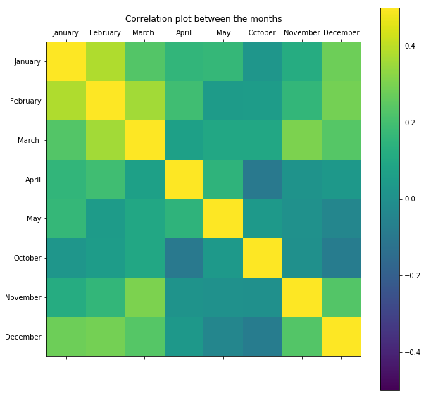

```python
correlations = df.iloc[:,1:9].corr()
# plot correlation matrix
fig = plt.figure(figsize=(10,10))
ax = fig.add_subplot(111)
cax = ax.matshow(correlations, vmin=-0.5, vmax=0.5)
fig.colorbar(cax)
ticks = np.arange(0,8,1)
ax.set_xticks(ticks)
ax.set_yticks(ticks)
ax.set_xticklabels(df.columns.values[1:9])
ax.set_yticklabels(df.columns.values[1:9])
ax.set_title("Correlation plot between the months")
plt.show()
```

#### 4. How is the trend of snowfall for each month over the years?

We use Simple Moving Average(SMA) for computing the moving averages over an window of 30 years. The main purpose of using moving averages is to smooth out any short term fluctuations in the data, this inturn allows us to visually more clearly the underlying trend in the dataset at hand.

From the below moving average plots, we can infer the following:

- We can clearly see that, snowfall during the months of October, April and May have nearly remained constant over the century with very few noticible fluctuations.
- The months November, February and March remain nearly constant until 1908 and show a gradually increasing snowfall trend until 1964, then start to decrease very gradually.
- It is highly evident that the months of January and December have very high snowfall and contribute the most to the total snowfall every year.
- The months December and January had a nearly constant snowfall until 1908 and shows drastic increase in the amount of snowfall until 1975, after which surprisingly the amount of snowfall starts decreasing.

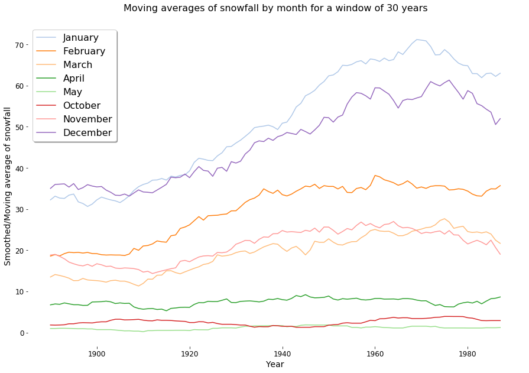

```python
import matplotlib.pyplot as plt
import numpy as np

tableau20 = [(31, 119, 180), (174, 199, 232), (255, 127, 14), (255, 187, 120),
             (44, 160, 44), (152, 223, 138), (214, 39, 40), (255, 152, 150),
             (148, 103, 189)]
tableau20 = np.array(tableau20)/255.0

plt.figure(figsize=(15,10)) # Sets size of plot.
ax=plt.subplot(111)
# Code to remove plot frame lines using spines function.
ax.spines['top'].set_visible(False)
ax.spines['bottom'].set_visible(False)
ax.spines['left'].set_visible(False)
ax.spines['right'].set_visible(False)

# Code to only show the tick marks on the left and bottom.
ax.get_xaxis().tick_bottom()
ax.get_yaxis().tick_left()

# Increase font size of ticks and label in the graph
ax.tick_params(labelsize=12)

plt.title("Moving averages of snowfall by month for a window of 30 years"+"\n", fontsize=16) # Set the plot title
plt.ylabel("Smoothed/Moving average of snowfall",fontsize=14) # Set the Y-Label
plt.xlabel("Year",fontsize=14) # Set the X-Label

def sliding_mean(data_array, window=30):
    slid_mean = []
    for i in range(0,len(data_array)-window):
        arr = np.array(data_array)
        slid_mean.append(np.sum(arr[i:(i+window)])/window)
    return slid_mean

for ind in range(1,9,1):
    plt.plot(df["Year"][:len(df["Year"])-30],sliding_mean(df.iloc[:,ind].transpose()),color=tableau20[ind], label=df.columns.values[ind])
    legend = plt.legend(loc='best', shadow=True, prop={'size': 16})
```

#### 5. What is the average snowfall per month? How is the snowfall distributed by month? Are there any abnormal snowfall records (Outliers)?

These questions can be better answered with a box plot which clearly indicates the five summary statistics such as minimum, first quartile,median, mean, third quartile which in our context indicates the average snowfall, spread of the amount of snowfall from the average for each month.

```python
traceOct = go.Box(
    y=df["October"],
    name='October',
    marker=dict(
        color='rgb(31, 119, 180)',
    ),
    boxmean='sd'
)

traceNov = go.Box(
    y=df["November"],
    name='November',
    marker=dict(
        color='rgb(10, 140, 208)',
    ),
    boxmean='sd'
)

traceDec = go.Box(
    y=df["December"],
    name='December',
    marker=dict(
        color='rgb(255, 127, 14)',
    ),
    boxmean='sd'
)

traceJan = go.Box(
    y=df["January"],
    name='January',
    marker=dict(
        color='rgb(255, 0, 255)',
    ),
    boxmean='sd'
)

traceFeb = go.Box(
    y=df["February"],
    name='February',
    marker=dict(
        color='rgb(44, 160, 44)',
    ),
    boxmean='sd'
)

traceMar = go.Box(
    y=df["March "],
    name='March',
    marker=dict(
        color='rgb(23, 190, 207)',
    ),
    boxmean='sd'
)

traceApr = go.Box(
    y=df["April"],
    name='April',
    marker=dict(
        color='rgb(214, 39, 128)',
    ),
    boxmean='sd'
)

traceMay = go.Box(
    y=df["May"],
    name='May',
    marker=dict(
        color='rgb(255, 152, 150)',
    ),
    boxmean='sd'
)

med = df.median()[1:9]
col5 = df.columns.values[1:9]
traceLine = go.Scatter(
    x=[col5[5],col5[6],col5[7],col5[0],col5[1],col5[3],col5[4]],
    y=[med[5],med[6],med[7],med[0],med[1],med[3],med[4]],
    mode="lines",
    name="Distribution",
    line = dict(shape= 'spline', smoothing= 1.3)
)

layout = go.Layout(
    title="Data Distribution and Outlier Detection",
    xaxis=dict(title="Months"),
    yaxis=dict(title="Snowfall(Inches)"),
    autosize=False,
    width=950,
    height=600
)
data = [traceOct,traceNov,traceDec,traceJan,traceFeb,traceMar,traceApr,traceMay,traceLine]

figBoxPlot = go.Figure(data=data,layout=layout)
iplot(figBoxPlot)
```

[interactive chart not shown]

#### 6. Are there any grouping patterns in the snowfall dataset?

This can be answered using a Cluster map which is a juxtaposed version of a dendogram and heatmap plots.

- A dendrogram is a tree diagram frequently used to illustrate the arrangement of the clusters produced by aglomerative hierarchical clustering.
- A heat map is a graphical representation of data where the individual values contained in a matrix are represented as colors.

Using a cluster map we can clearly see the amount of snowfall over the years at a glance.

- Also we can see which years have had similar amount of snowfall.
- The clustermap also indicates which months have similar snowfall.
- By looking at the clustermap below and the column dendogram, we see a clear distinction of months into 3 clusters (naming it as Low Snowfall, Moderate snowfall and High Snowfall) ordered by intensity of the snowfall.

```
Text(0.62,0.9,u'Snowfall cluster by month')
```

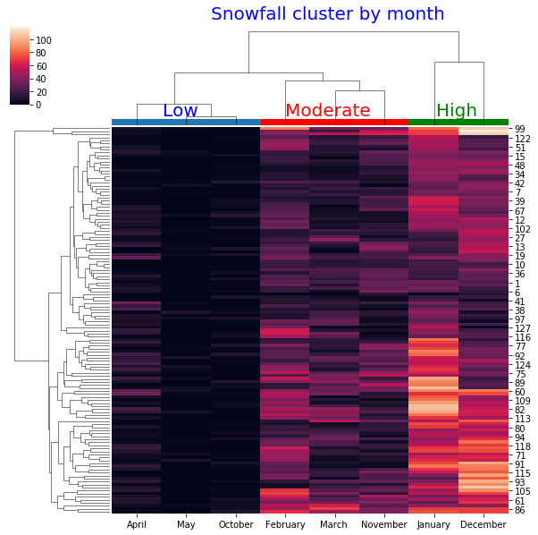

```python
import seaborn as sns
import matplotlib.patches as patches

ax = sns.clustermap(df.iloc[:,1:9])
ax.ax_col_dendrogram.add_patch(
    patches.Rectangle(
        (0, 0),   # (x,y)
        30,          # width
        30,          # height
    )
)
ax.ax_col_dendrogram.add_patch(
    patches.Rectangle(
        (30, 0),   # (x,y)
        30,          # width
        30,          # height
        facecolor="red"
    )
)
ax.ax_col_dendrogram.add_patch(
    patches.Rectangle(
        (60, 0),   # (x,y)
        30,          # width
        30,          # height
        facecolor="green"
    )
)
left, width = .25, .5
bottom, height = .25, .5
right = left + width
top = bottom + height
ax.fig.text(0.62*(left+right), 0.75*(bottom+top), 'Moderate',
        horizontalalignment='center',
        verticalalignment='center',
        fontsize=20, color='red')
ax.fig.text(0.82*(left+right), 0.75*(bottom+top), 'High',
        horizontalalignment='center',
        verticalalignment='center',
        fontsize=20, color='green')
ax.fig.text(0.39*(left+right), 0.75*(bottom+top), 'Low',
        horizontalalignment='center',
        verticalalignment='center',
        fontsize=20, color='blue')
ax.fig.text(0.62*(left+right), 0.9*(bottom+top), 'Snowfall cluster by month',
        horizontalalignment='center',
        verticalalignment='center',
        fontsize=20, color='blue')
```